# ‘MCMCvis’ package

Casey Youngflesh, Christian Che-Castaldo

## Intro

`MCMCvis` is an R package used to visualize, manipulate, and summarize MCMC output. This may be Bayesian model output fit with Stan, NIMBLE, JAGS, and other software.

The package contains six functions:

- `MCMCsummary` - summarize MCMC output for particular parameters of interest
- `MCMCpstr` - summarize MCMC output and extract posterior chains for particular parameters of interest while preserving parameter structure
- `MCMCtrace` - create trace and density plots of MCMC chains for particular parameters of interest
- `MCMCchains` - extract posterior chains from MCMC output for particular parameters of interest
- `MCMCplot` - create caterpillar plots from MCMC output for particular parameters of interest
- `MCMCdiag` - create a `.txt` file and save specified objects that summarize model inputs, outputs, and diagnostics

`MCMCvis` was designed to perform key functions for MCMC analysis using minimal code, in order to free up time/brainpower for interpretation of analysis results. Functions support simple and straightforward subsetting of model parameters within the calls, and produce presentable, ‘publication-ready’ output.

All functions in the package accept `stanfit` objects (created with the `rstan` package), `stanreg` objects (created with the `rstanarm` package), `brmsfit` objects (created with the `brms` package), `mcmc.list` objects (created with the `rjags` or `coda` packages), `mcmc` objects (created with the `coda` or `nimble` packages), `list` objects (created with the `nimble` package), `R2jags` output (created with the `R2jags` package), `jagsUI` output (created with the `jagsUI` package), and matrices of MCMC output (chains combined into a single column per parameter - columns to be named with parameter names). The functions automatically detect the object type and proceed accordingly. Model output objects can be inserted directly into the `MCMCvis` functions as an argument.

#### JAGS model

```r
library(rjags)

# create JAGS model
mf <- "
model {
for (i in 1:10)
{
  y[i] ~ dnorm(mu, 0.01);
}
mu ~ dnorm(0, 0.01)
}
"

data <- list(y = rnorm(10))

jm <- rjags::jags.model(
  textConnection(mf),
  data = data,
  n.chains = 3)

jags_out <- rjags::coda.samples(
  jm,
  variable.names = 'mu',
  n.iter = 500)
```

```r
library(MCMCvis)
```

```r
MCMCsummary(jags_out, round = 2)
```

```r
##     mean   sd  2.5%   50% 97.5% Rhat n.eff
## mu -0.28 2.97 -6.13 -0.14  5.22    1  1397
```

#### NIMBLE model

```r
library(nimble)

# create NIMBLE model
mf2 <- nimbleCode({
  for (i in 1:10) {
    y[i] ~ dnorm(mu, 0.01);
  }
  mu ~ dnorm(0, 0.01)
})

nimble_out <- nimbleMCMC(
  code = mf2,
  constants = list(N = 10),
  data = data,
  inits = list(mu = 0),
  nchains = 4,
  niter = 500)
```

```r
MCMCsummary(nimble_out, round = 2)
```

```r
##     mean   sd  2.5%   50% 97.5% Rhat n.eff
## mu -0.03 2.99 -5.76 -0.1  5.88    1  2000
```

#### Stan model

```r
library(rstan)

# create Stan model
sm <- "
data {
  real y[10];
}
parameters {
  real mu;
}
model {
  for (i in 1:10) {
    y[i] ~ normal(mu, 10);
  }
  mu ~ normal(0, 10);
}
"

stan_out <- stan(
  model_code = sm,
  data = data,
  iter = 500)
```

```r
MCMCsummary(stan_out, round = 2)
```

```r
##       mean   sd  2.5%   50% 97.5% Rhat n.eff
## mu   -0.51 2.82 -6.06 -0.36  5.07 1.01   414
## lp__ -0.45 0.61 -2.27 -0.23 -0.01 1.00   508
```

## MCMCsummary

`MCMCsummary` is used to output summary information from MCMC output as a data.frame. All digits are reported by default.

We’ll use the built in `mcmc.list` object for the examples below, but model output of any of the supported types will behave in the same way.

```r
MCMCsummary(MCMC_data)
```

```
##                mean        sd       2.5%        50%      97.5% Rhat n.eff
## alpha[1]  -9.775030  2.087347 -13.873736  -9.747235  -5.718132    1 10406
## alpha[2] -10.954077  4.087058 -18.986880 -10.996852  -2.932785    1 10807
## alpha[3] -12.812863  5.345266 -23.334561 -12.833156  -2.505842    1 10500
## alpha[4] -13.162363  4.549087 -22.002841 -13.131785  -4.270300    1 11160
## alpha[5] -11.683834  8.888936 -28.857696 -11.734387   6.059936    1 10253
## alpha[6]  -8.272228  6.200246 -20.263314  -8.218744   3.889713    1 10500
## beta[1]   -4.618601  6.544247 -17.193329  -4.619954   8.378438    1 10411
## beta[2]  -14.169569  6.633089 -27.152037 -14.084978  -1.414025    1 10500
## beta[3]  -35.936571  8.415110 -52.599736 -35.998599 -19.259210    1 10884
## beta[4]    6.172961 10.716345 -14.670444   6.110057  27.266086    1 10500
## beta[5]    8.423471  3.463758   1.625696   8.447591  15.125755    1 10500
## beta[6]  -12.051330  2.336788 -16.655170 -12.046641  -7.537826    1 10500
```

The number of decimal places displayed can be specified with `round` (except for Rhat which is always rounded to 2 decimal places and n.eff which always displays whole numbers). Alternatively, the significant digits displayed can be specified with `digits`.

```r
MCMCsummary(MCMC_data, round = 2)
```

```
##            mean    sd   2.5%    50%  97.5% Rhat n.eff
## alpha[1]  -9.78  2.09 -13.87  -9.75  -5.72    1 10406
## alpha[2] -10.95  4.09 -18.99 -11.00  -2.93    1 10807
## alpha[3] -12.81  5.35 -23.33 -12.83  -2.51    1 10500
## alpha[4] -13.16  4.55 -22.00 -13.13  -4.27    1 11160
## alpha[5] -11.68  8.89 -28.86 -11.73   6.06    1 10253
## alpha[6]  -8.27  6.20 -20.26  -8.22   3.89    1 10500
## beta[1]   -4.62  6.54 -17.19  -4.62   8.38    1 10411
## beta[2]  -14.17  6.63 -27.15 -14.08  -1.41    1 10500
## beta[3]  -35.94  8.42 -52.60 -36.00 -19.26    1 10884
## beta[4]    6.17 10.72 -14.67   6.11  27.27    1 10500
## beta[5]    8.42  3.46   1.63   8.45  15.13    1 10500
## beta[6]  -12.05  2.34 -16.66 -12.05  -7.54    1 10500
```

Specific parameters can be specified to subset summary information. Square brackets in parameter names are ignored by default. For instance, all `alpha` parameters can be plotted using `params = 'alpha'`.

```r
MCMCsummary(MCMC_data,
            params = 'alpha',
            round = 2)
```

```
##            mean   sd   2.5%    50% 97.5% Rhat n.eff
## alpha[1]  -9.78 2.09 -13.87  -9.75 -5.72    1 10406
## alpha[2] -10.95 4.09 -18.99 -11.00 -2.93    1 10807
## alpha[3] -12.81 5.35 -23.33 -12.83 -2.51    1 10500
## alpha[4] -13.16 4.55 -22.00 -13.13 -4.27    1 11160
## alpha[5] -11.68 8.89 -28.86 -11.73  6.06    1 10253
## alpha[6]  -8.27 6.20 -20.26  -8.22  3.89    1 10500
```

Individual parameters can also be specified. For example, one `alpha` (of many) may be specified. In this case, the square brackets should not be ignored, so that only the `alpha[1]` parameter can be specified. Use the argument `ISB = FALSE` to prevent square brackets from being ignored (ISB is short for ‘Ignore Square Brackets’). The `exact` argument can be used to specify whether the parameter name should be matched exactly (after taking into account the `ISB` argument). Therefore, to return a single `alpha` parameter, `ISB = FALSE` and `exact = TRUE` can be used in the following way.

```r
MCMCsummary(MCMC_data,
            params = 'alpha[1]',
            ISB = FALSE,
            exact = TRUE,
            round = 2)
```

```
##           mean   sd   2.5%   50% 97.5% Rhat n.eff
## alpha[1] -9.78 2.09 -13.87 -9.75 -5.72    1 10406
```

When `exact = FALSE`, the `params` argument reads like a regular expression. Because of this, square brackets must be escaped with `\\`. All other regular expression syntax is accepted, as typically applied in R. This can be useful for returning a specific set of a large number of parameters. A great tools for regular expressions in R can be found here (https://regexr.com/) (though note two slashes are needed to escape characters in this function rather than one, hence `\\[` as opposed to `\[`). `\\d` can be used to specify any digits in a particular place.

```r
MCMCsummary(MCMC_data,
            params = 'alpha\\[1\\]',
            ISB = FALSE,
            exact = FALSE,
            round = 2)
```

```
##           mean   sd   2.5%   50% 97.5% Rhat n.eff
## alpha[1] -9.78 2.09 -13.87 -9.75 -5.72    1 10406
```

The `excl` argument can be used to exclude any parameters. For instance, if all parameters are desired **except** for the `alphas`, use `params = 'all', excl = 'alpha', ISB = FALSE, exact = FALSE`. These arguments can be used in any of the functions in the package.

```r
MCMCsummary(MCMC_data,
            params = 'all',
            excl = 'alpha',
            ISB = FALSE,
            exact = FALSE,
            round = 2)
```

```
##           mean    sd   2.5%    50%  97.5% Rhat n.eff
## beta[1]  -4.62  6.54 -17.19  -4.62   8.38    1 10411
## beta[2] -14.17  6.63 -27.15 -14.08  -1.41    1 10500
## beta[3] -35.94  8.42 -52.60 -36.00 -19.26    1 10884
## beta[4]   6.17 10.72 -14.67   6.11  27.27    1 10500
## beta[5]   8.42  3.46   1.63   8.45  15.13    1 10500
## beta[6] -12.05  2.34 -16.66 -12.05  -7.54    1 10500
```

Setting the `Rhat` and `n.eff` arguments to `FALSE` can be used to avoid calculating the Rhat statistic and number of effective samples, respectively (defaults for both `Rhat` and `n.eff` are `TRUE`). Specifying `FALSE` may greatly increase function speed with very large `mcmc.list` objects. Values for Rhat near 1 suggest convergence (Brooks and Gelman 1998). Rhat and n.eff values for `mcmc.list` objects are calculated using the `coda` package (what is typically returned by packages that utilize JAGS). Rhat and n.eff values for `stanfit` and `jagsUI` objects are calculated using a ‘split chain’ Rhat (as used by their respective packages). The approaches differ slightly between the `coda` and `stanfit`/`jagsUI` packages. Details on calculation of Rhat and number of effective samples using `rstan` can be found in the Stan manual (Stan Development Team 2018).

```r
MCMCsummary(MCMC_data,
            params = 'alpha',
            Rhat = TRUE,
            n.eff = TRUE,
            round = 2)
```

```
##            mean   sd   2.5%    50% 97.5% Rhat n.eff
## alpha[1]  -9.78 2.09 -13.87  -9.75 -5.72    1 10406
## alpha[2] -10.95 4.09 -18.99 -11.00 -2.93    1 10807
## alpha[3] -12.81 5.35 -23.33 -12.83 -2.51    1 10500
## alpha[4] -13.16 4.55 -22.00 -13.13 -4.27    1 11160
## alpha[5] -11.68 8.89 -28.86 -11.73  6.06    1 10253
## alpha[6]  -8.27 6.20 -20.26  -8.22  3.89    1 10500
```

Sample quantiles in MCMCsummary can now be specified directly using the `probs` argument, removing the need to define custom quantiles with the `func` argument. The default behavior is to provide 2.5%, 50%, and 97.5% quantiles. These probabilities can be changed by supplying a numeric vector to the `probs` argument.

```r
MCMCsummary(MCMC_data,
            params = 'alpha',
            Rhat = TRUE,
            n.eff = TRUE,
            probs = c(0.1, 0.5, 0.9),
            round = 2)
```

```
##            mean   sd    10%    50%   90% Rhat n.eff
## alpha[1]  -9.78 2.09 -12.47  -9.75 -7.13    1 10406
## alpha[2] -10.95 4.09 -16.18 -11.00 -5.67    1 10807
## alpha[3] -12.81 5.35 -19.76 -12.83 -6.10    1 10500
## alpha[4] -13.16 4.55 -19.06 -13.13 -7.29    1 11160
## alpha[5] -11.68 8.89 -23.03 -11.73 -0.36    1 10253
## alpha[6]  -8.27 6.20 -16.34  -8.22 -0.31    1 10500
```

Setting `HPD = TRUE` will cause MCMCsummary to use `HPDinterval` from the `coda` package to compute highest posterior density intervals based on the probability specified in the `hpd_prob` argument (this argument is different than `probs` argument, which is reserved for quantiles). Note that for each parameter `HPDinterval` normally returns one interval per chain. However, MCMCsummary first pools the chains, forcing `HPDinterval` to compute a single interval across all posterior samples for each parameter. This step is done for user convenience.

```r
MCMCsummary(MCMC_data,
            params = 'alpha',
            Rhat = TRUE,
            n.eff = TRUE,
            HPD = TRUE,
            hpd_prob = 0.8,
            round = 2)
```

```
##            mean   sd 80%_HPDL 80%_HPDU Rhat n.eff
## alpha[1]  -9.78 2.09   -12.38    -7.05    1 10406
## alpha[2] -10.95 4.09   -16.03    -5.58    1 10807
## alpha[3] -12.81 5.35   -19.80    -6.15    1 10500
## alpha[4] -13.16 4.55   -19.44    -7.74    1 11160
## alpha[5] -11.68 8.89   -23.18    -0.57    1 10253
## alpha[6]  -8.27 6.20   -16.14    -0.15    1 10500
```

The `func` argument can be used to return metrics of interest not already returned by default for `MCMCsummary`. Input is a function to be performed on posteriors for each specified parameter. Values returned by the function will be displayed as a column in the summary output (or multiple columns if the function returns more than one value). In this way, functions from other packages can be used to derive metrics of interest on posterior output. Column name(s) for function output can be specified with the `func_name` argument. The example below uses the empirical cumulative distribution function `ecdf` to compute the proportion of posterior samples that are less than -10 for each `alpha` parameter. The argument `pg0` can be used to specify whether to calculate the proportion of the posterior that is greater than 0.

```r
MCMCsummary(MCMC_data,
            params = 'alpha',
            Rhat = TRUE,
            n.eff = TRUE,
            round = 2,
            func = function(x) ecdf(x)(-10), func_name = "ecdf-10",
            pg0 = TRUE)
```

```
##            mean   sd   2.5%    50% 97.5% Rhat n.eff  p>0 ecdf-10
## alpha[1]  -9.78 2.09 -13.87  -9.75 -5.72    1 10406 0.00    0.45
## alpha[2] -10.95 4.09 -18.99 -11.00 -2.93    1 10807 0.00    0.60
## alpha[3] -12.81 5.35 -23.33 -12.83 -2.51    1 10500 0.01    0.70
## alpha[4] -13.16 4.55 -22.00 -13.13 -4.27    1 11160 0.00    0.75
## alpha[5] -11.68 8.89 -28.86 -11.73  6.06    1 10253 0.09    0.58
## alpha[6]  -8.27 6.20 -20.26  -8.22  3.89    1 10500 0.09    0.39
```

## MCMCpstr

`MCMCpstr` is used to output summary information and posterior chains from MCMC output while preserving the original structure of the specified parameters (i.e., scalar, vector, matrix, array). Preserving the original structure can be helpful when plotting or summarizing parameters with multidimensional structure. Particular parameters of interest can be specified as with other functions with the `params` argument.

Function output has two types. When `type = 'summary'` (the default), a `list` with calculated values for each specified parameter is returned, similar to output obtained when fitting models with the `jags.samples` function (as opposed to `coda.samples`) from the `rjags` package.

The function calculates summary information only for the specified function. The function to be used is specified using the `func` argument.

```r
MCMCpstr(MCMC_data,
         params = 'alpha',
         func = mean,
         type = 'summary')
```

```
## $alpha
## [1]  -9.775030 -10.954077 -12.812863 -13.162363 -11.683834  -8.272228
```

Custom functions can be specified as well. If the output length of the specified function is greater than 1 when `type = 'summary'`, an extra dimension is added to the function output. For instance, a `vector` becomes a `matrix`, a `matrix` a three dimensional `array`, and so forth.

```r
MCMCpstr(MCMC_data, func = function(x) quantile(x, probs = c(0.01, 0.99)))
```

```
## $alpha
##                 1%        99%
## alpha[1] -14.74923 -5.0484174
## alpha[2] -20.43502 -1.5155018
## alpha[3] -25.32232 -0.4924355
## alpha[4] -23.58314 -2.4859330
## alpha[5] -32.38629  8.8685816
## alpha[6] -22.56589  6.0892554
##
## $beta
##                1%        99%
## beta[1] -19.75530  10.840028
## beta[2] -30.05090   1.018119
## beta[3] -55.61435 -16.135057
## beta[4] -18.86956  30.939547
## beta[5]   0.48582  16.198588
## beta[6] -17.60307  -6.658913
```

When `type = 'chains'`, a `list` with posterior chain values for each specified parameter is returned. The structure of the parameter is preserved - posterior chain values are concatenated and placed in an additional dimension. For instance, output for a vector parameter will be in `matrix` format for that element of the `list`. Similarly, output for a matrix parameter will be in a three dimensional `array`.

```r
ex <- MCMCpstr(MCMC_data, type = 'chains')
dim(ex$alpha)
```

```
## [1]     6 10500
```

## MCMCtrace

`MCMCtrace` is used to create trace and density plots for MCMC output. This is useful for diagnostic purposes. Particular parameters can also be specified, as with `MCMCsummary`. Output is written to PDF by default to enable more efficient review of posteriors - this also reduces computation time. PDF output is particularly recommended for large numbers of parameters. `pdf = FALSE` can be used to prevent output to PDF.

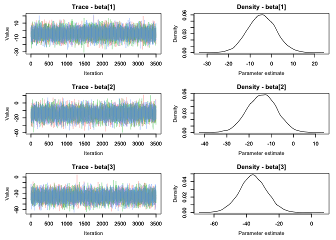

```r
MCMCtrace(MCMC_data,
          params = c('beta[1]', 'beta[2]', 'beta[3]'),
          ISB = FALSE,
          exact = TRUE,
          pdf = FALSE)
```

Just trace plots can be plotted with `type = 'trace'`. Just density plots can be plotted with `type = 'density'`. Default is `type = 'both'` which outputs both trace and density plots. Density plots for individual chains can be output using the `ind` argument.

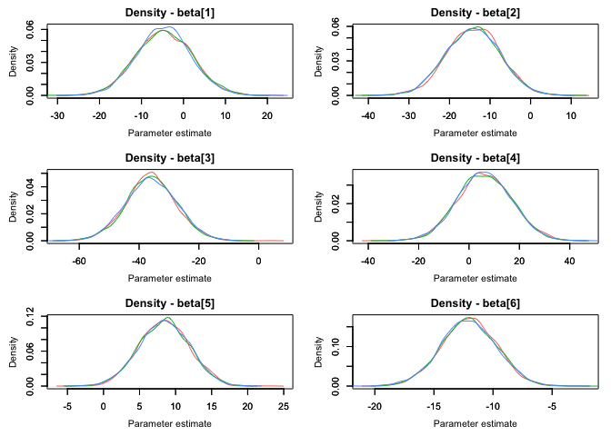

```r
MCMCtrace(MCMC_data,
          params = 'beta',
          type = 'density',
          ind = TRUE,
          pdf = FALSE)
```

The PDF document will be output to the current working directory by default, but another directory can be specified. The `open_pdf` argument can be used to prevent the produced PDF from opening in a viewer once generated.

```r
MCMCtrace(MCMC_data,
          pdf = TRUE,
          open_pdf = FALSE,
          filename = 'MYpdf',
          wd = 'DIRECTORY_HERE')
```

`iter` denotes how many iterations should be plotted for the chain the trace and density plots. The default is 5000, meaning that the last 5000 iterations of each chain are plotted. Remember, this is the final posterior chain, not including the specified burn-in or warm-up (specified when the model was run). If less than 5000 iterations are run, the full number of iterations will be plotted.

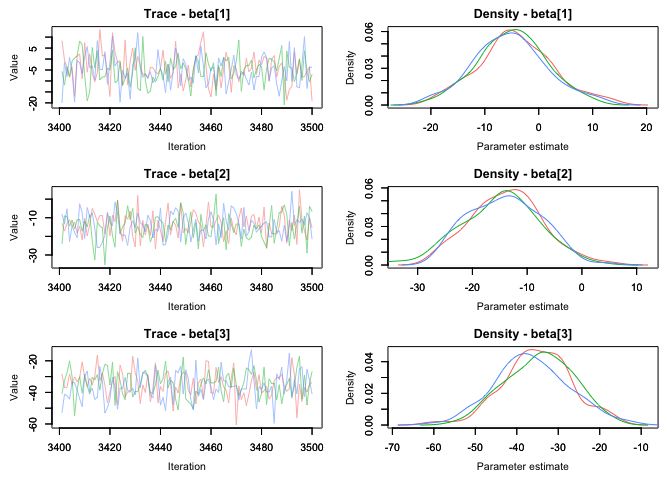

```r
MCMCtrace(MCMC_data,
          params = c('beta[1]', 'beta[2]', 'beta[3]'),
          ISB = FALSE,
          exact = TRUE,
          iter = 100,
          ind = TRUE,
          pdf = FALSE)
```

Overlap between the priors and posteriors (PPO - prior posterior overlap) can also be calculated by specifying the priors associated with each parameter using the `priors` argument. This is particularly useful when investigating how large the effect of the prior is on the posterior distribution - this can be informative when trying to determine how identifiable a particular parameter is in a model.

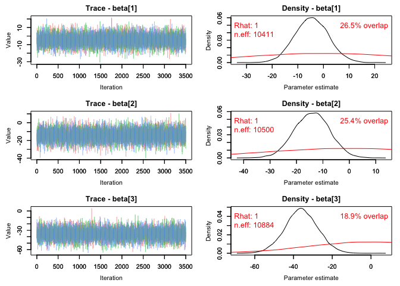

```r
# note that the same prior used for all parameters
# the following prior is equivalent to dnorm(0, 0.001) in JAGS
PR <- rnorm(15000, 0, 32)

MCMCtrace(MCMC_data,
          params = c('beta[1]', 'beta[2]', 'beta[3]'),
          ISB = FALSE,
          exact = TRUE,
          priors = PR,
          pdf = FALSE,
          Rhat = TRUE,
          n.eff = TRUE)
```

Plots can be scaled to visualize both the posterior and the prior distribution using the `post_zm` argument.

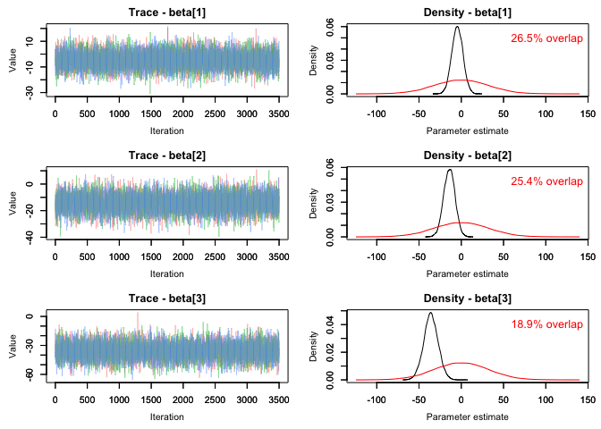

```r
MCMCtrace(MCMC_data,
          params = c('beta[1]', 'beta[2]', 'beta[3]'),
          ISB = FALSE,
          exact = TRUE,
          priors = PR,
          pdf = FALSE,
          post_zm = FALSE)
```

Percent overlap can be output to an R object as well using the `PPO_out` argument. Plotting of the trace plots can be suppressed with `plot = FALSE`.

```r
PPO <- MCMCtrace(MCMC_data,
                 params = c('beta[1]', 'beta[2]', 'beta[3]'),
                 ISB = FALSE,
                 exact = TRUE,
                 priors = PR,
                 plot = FALSE,
                 PPO_out = TRUE)
PPO
```

```
##     param percent_PPO
## 1 beta[1]        26.5
## 2 beta[2]        25.4
## 3 beta[3]        18.9
```

Additional arguments can be used to change the limits of the density plots, axes labels, plot titles, line width and type, size and color of text, tick and axes label size, position of ticks, color of lines, and thickness of axes.

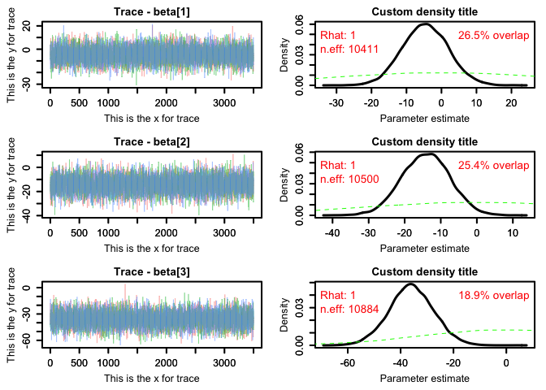

```r
MCMCtrace(MCMC_data,
          params = c('beta[1]', 'beta[2]', 'beta[3]'),
          ISB = FALSE,
          exact = TRUE,
          priors = PR,
          pdf = FALSE,
          Rhat = TRUE,
          n.eff = TRUE,
          xlab_tr = 'This is the x for trace',
          ylab_tr = 'This is the y for trace',
          main_den = 'Custom density title',
          lwd_den = 3,
          lty_pr = 2,
          col_pr = 'green',
          sz_txt = 1.3,
          sz_ax = 2,
          sz_ax_txt = 1.2,
          sz_tick_txt = 1.2,
          sz_main_txt = 1.3)
```

If simulated data were used to fit the model, the generating values used to simulate the data can be specified using the `gvals` argument. This makes it possible to compare posterior estimates with the true parameter values. Generating values will be displayed as vertical dotted lines. Similar to the `priors` argument, if one value is specified when more than one parameter is used, this one generating value will be used for all parameters.

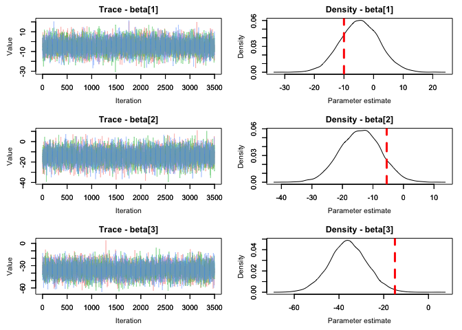

```r
# generating values for each parameter used to simulate data
GV <- c(-10, -5.5, -15)

MCMCtrace(MCMC_data,
          params = c('beta[1]', 'beta[2]', 'beta[3]'),
          ISB = FALSE,
          exact = TRUE,
          gvals = GV,
          pdf = FALSE)
```

## MCMCchains

`MCMCchains` is used to extract posterior chains from MCMC objects. Chains can then be manipulated directly. Particular parameters can be specified as with other functions.

```r
ex <- MCMCchains(MCMC_data, params = 'beta')
```

Extract mean values for each parameter:

```r
apply(ex, 2, mean)
```

```
##    beta[1]    beta[2]    beta[3]    beta[4]    beta[5]    beta[6]
##  -4.618601 -14.169569 -35.936571   6.172961   8.423471 -12.051330
```

Using the `mcmc.list` argument, `MCMCchains` can return an `mcmc.list` object, instead of a matrix, for the specified parameters. This can be useful when saving posterior information for only a subset of parameters is desired.

```r
ex2 <- MCMCchains(MCMC_data,
                  params = 'beta',
                  mcmc.list = TRUE)
```

## MCMCplot

`MCMCplot` is used to create caterpillar plots from MCMC output. Points represent posterior medians. Thick and thin lines represent credible intervals specified by the user using the `ci` argument, where the default is 50% and 95% credible intervals, respectively. Note, that the first element in `ci` should be less than or equal to the second element. By default, `MCMCplot` plots equal-tailed credible intervals (`HPD = FALSE`). However, highest posterior density intervals can be visualized using `HPD = TRUE`. As with the other functions in the package, particular parameters of interest can be specified.

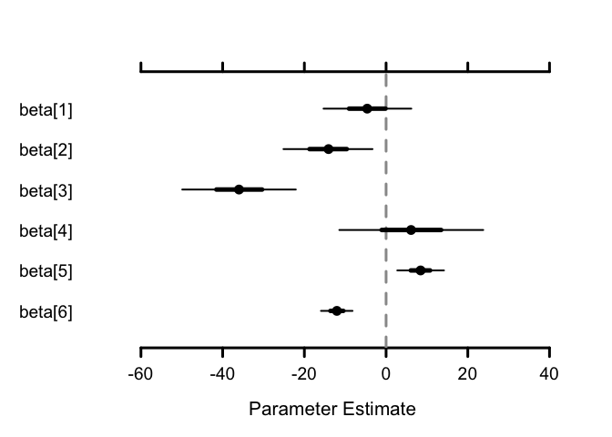

```r
MCMCplot(MCMC_data,
         params = 'beta',
         ci = c(50, 90))
```

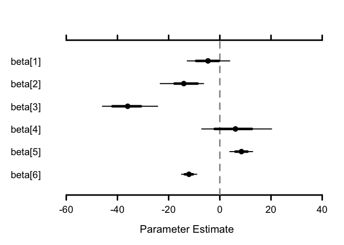

```r
MCMCplot(MCMC_data,
         params = 'beta',
         ci = c(50, 80),
         HPD = TRUE)
```

`ref_ovl = TRUE` can be used to change how the posterior estimates are plotted based on the credible intervals. Parameters whose `ci[1]` (higher precision / lower certainty) credible intervals overlap 0 are indicated by ‘open’ circles. Parameters whose `ci[1]` credible intervals DO NOT overlap 0 AND whose `ci[2]` (lower precision / higher certainty) credible intervals DO overlap 0 are indicated by ‘closed’ gray circles. Parameters whose `ci[2]` credible intervals DO NOT overlap 0 are indicated by ‘closed’ black circles. A vertical reference at 0 is plotted by default. The position of this reference line can be modified with the `ref` argument. `ref = NULL` removes the reference line altogether.

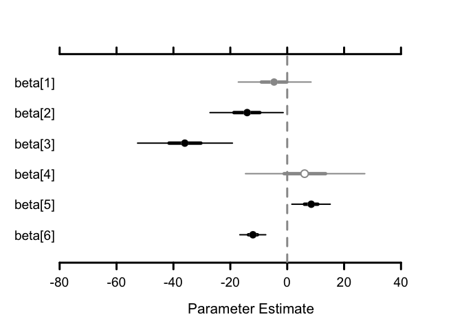

```r
MCMCplot(MCMC_data,
         params = 'beta',
         ref_ovl = TRUE)
```

Parameters can be ranked by posterior median estimates using the `rank` argument. `xlab` can be used to create an alternative label for the x-axis. Guidelines can be produced using the `guide_lines` argument. This can be helpful when there are a large number of parameters and matching labels to plotted ‘caterpillars’ becomes difficult.

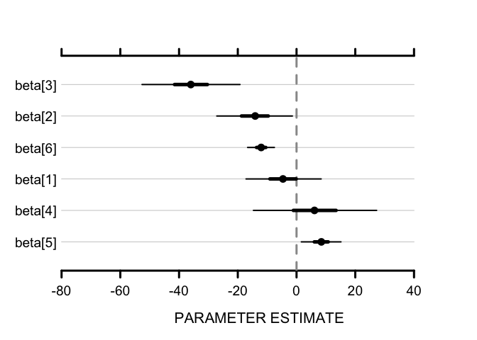

```r
MCMCplot(MCMC_data,
         params = 'beta',
         rank = TRUE,
         xlab = 'PARAMETER ESTIMATE',
         guide_lines = TRUE)
```

The orientation of the plot can also be change using the `horiz` argument. `ylab` is then used to specify an alternative label on the ‘estimate axis’.

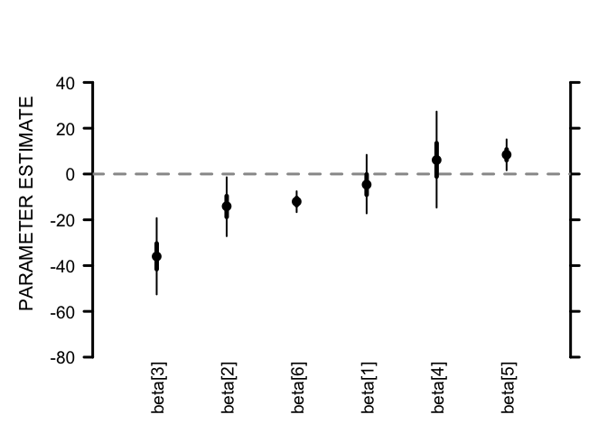

```r
MCMCplot(MCMC_data,
         params = 'beta',
         rank = TRUE,
         horiz = FALSE,
         ylab = 'PARAMETER ESTIMATE')
```

Output from two models can also be plotted side-by-side, as long as the parameter names are identical (NOTE: not ALL parameters need to be identical, just the parameters specified in the `params` argument). This is useful for comparing output from similar models. By default, the the first model input (`object`) will be plotted in black, while the second model input (`object2`) will be plotted in red. Different colors for each model output can be specified with `col` and `col2`. The spacing between the plotted posteriors for each parameter can be adjusted with `offset` (as the desired spacing will depend on the size of the image as well as the specified thickness/size of the lines/dots). The `ref_ovl` argument can also be specified.

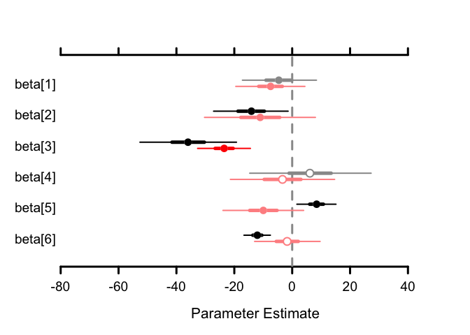

```r
MCMCplot(object = MCMC_data,
         object2 = MCMC_data2,
         params = 'beta',
         offset = 0.1,
         ref_ovl = TRUE)
```

Graphical parameters for x and y-axis limitation, row labels, title, median dot size, CI line thickness, axis and tick thickness, text size, color of posterior estimates, and margins can be specified.

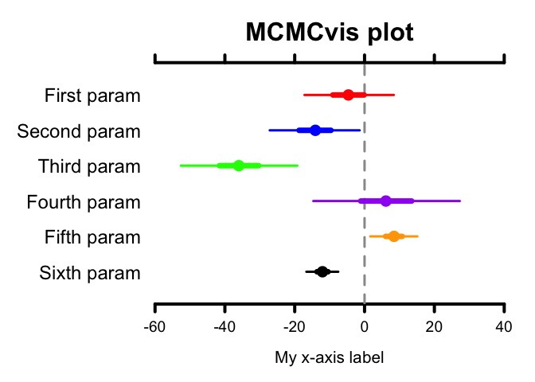

```r
MCMCplot(MCMC_data,
         params = 'beta',
         xlim = c(-60, 40),
         xlab = 'My x-axis label',
         main = 'MCMCvis plot',
         labels = c('First param', 'Second param', 'Third param',
                    'Fourth param', 'Fifth param', 'Sixth param'),
          col = c('red', 'blue', 'green', 'purple', 'orange', 'black'),
          sz_labels = 1.5,
          sz_med = 2,
          sz_thick = 7,
          sz_thin = 3,
          sz_ax = 4,
          sz_main_txt = 2)
```

Other elements can be added to `MCMCplot` figures as well. For instance, to add PPO (prior posterior overlap) to the posterior plot, first calculate PPO using the `MCMCtrace` function (with `PPO_out = TRUE` and `plot = FALSE` to suppress plotting).

```r
# note that the same prior used for all parameters
# the following prior is equivalent to dnorm(0, 0.001) in JAGS
PR <- rnorm(15000, 0, 32)

PPO <- MCMCtrace(MCMC_data,
                 params = c('beta[1]', 'beta[2]', 'beta[3]'),
                 ISB = FALSE,
                 exact = TRUE,
                 priors = PR,
                 plot = FALSE,
                 PPO_out = TRUE)
```

Then use `MCMCplot` to create the posterior plot and loop to plot PPO as text on plot.

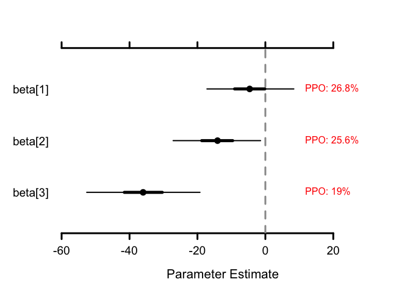

```r
MCMCplot(MCMC_data,
         params = c('beta[1]', 'beta[2]', 'beta[3]'),
          ISB = FALSE,
          exact = TRUE,
          xlim = c(-60, 35))

# each parameter is a y-unit of 1
for (i in 1:NROW(PPO)) {
  text(x = 10, y = NROW(PPO) - i + 1, paste0('PPO: ', PPO[i,2], '%'), pos = 4, col = 'red')
}
```

## MCMCdiag

`MCMCdiag` is used to create a `.txt` file to summarize model inputs, output, and diagnostics. Options can be specified to save model output as an `.rds` file, create a new directory to store this file, save other objects of interest (such as data files or session information) as `.rds` files, and to copy files of interest (such as the version of the `R` script used to fit a model or the associated `.stan` or `.jags` file) to the created directory.

Output presented in the `.txt` file varies by model fit object type but includes: model run time, number of warmup/burn-in iterations, total iterations, thinning rate, number of chains, specified adapt delta, specified max tree depth, specific initial step size, mean accept stat, mean tree depth, mean step size, number of divergent transitions, number max tree depth exceeds, number of chains with BFMI warnings, max Rhat (maximum Rhat of any parameter printed), min n.eff (minimum n.eff of any parameter printed), parameter summary information (arguments from `MCMCsummary` are accepted to modify this summary information), and any additional information fed to the `add_field` argument. See documentation for specific software used to fit model for more information on particular diagnostics. As with the other functions in the package, particular parameters of interest can be specified for the summary information (though typically all parameters will be of interest as the purpose of this function is to have a record of the summary information).

This function can facilitate more reproducible workflows and more organized versioning of model results. For instance the following function call:

- Creates a directory within `Results/` named `model-YYYY-MM-DD/`
- Saves a `.txt` file named `model-summary-YYYY-MM-DD.txt` within that new directory containing model inputs, outputs, and diagnostics (with an additional user-specified field denoting the data version used to fit the model)
- Saves the `model_fit` object provided to the function as a `.rds` file (named `model-fit-YYYY-MM-DD.rds`) within the new directory
- Saves the `DATA` object (in this case, used to fit the model) as a `.rds` file (named `model-data-YYYY-MM-DD.rds`)
- Saves the output from `sessionInfo`, which provides information on the `R` session when the function was run as a `.rds` file (named `session-info-YYYY-MM-DD.rds`)
- Copies two files, `model.stan` (`.stan` file specifying the model) and `fit-model.R` (the script used to fit the model) into the new directory as `model-YYYY-MM-DD.stan` and `fit-model-YYYY-MM-DD.R`, respectively

```r
MCMCdiag(model_fit,
         round = 3,
         file_name = 'model-summary-YYYY-MM-DD',
         dir = 'Results',
         mkdir = 'model-YYYY-MM-DD',
         add_field = '1.0',
         add_field_names = 'Data version',
         save_obj = TRUE,
         obj_name = 'model-fit-YYYY-MM-DD',
         add_obj = list(DATA, sessionInfo()),
         add_obj_names = c('model-data-YYYY-MM-DD', 'session-info-YYYY-MM-DD'),
         cp_file = c('model.stan', 'fit-model.R'),
         cp_file_names = c('model-YYYY-MM-DD.stan, fit-model-YYYY-MM-DD.R'))
```

In this way, a complete record of the script, the model file, and the data used to fit the model, the model output, `R` session information, and a summary of the model output are stored in a dated directory. Results from a particular model run can then be easily referenced in the future. A particular version of the model/data can be easily rerun using these resources. While this is one use case, any combination of options can be used and any additional objects can be saved and files copied depending on the desires of the user.

## References

Brooks, S. P., and A. Gelman. 1998. General methods for monitoring convergence of iterative simulations. Journal of Computational and Graphical Statistics 7:434.

Stan Development Team. 2018. Stan Modeling Language Users Guide and Reference Manual, Version 2.18.0. https://mc-stan.org

**For more information see `?MCMCvis`**